# Client Report - Project 4

- Show All Code
- Hide All Code

Course DS 250

Author

Victor Affleck

## Introduction

In this presentation we will be going over some concepts of machine learning using data from Colorado concerning the clean air act of 1970. Mainly discussing topics that would allow us to build a predictive model that can cliassify if a house is build pre 1980.

**Read and format project data**

```python
# Include and execute your code here
df = pd.read_csv("https://raw.githubusercontent.com/byuidatascience/data4dwellings/master/data-raw/dwellings_ml/dwellings_ml.csv")
```

## Exploring potential relationships between homes built before 1980

Create 2-3 charts that evaluate potential relationships between the home variables and before1980. Explain what you learn from the charts that could help a machine learning algorithm.

For building types that are higher we can tell the algorithm that if it sees a building with no garage or a detached garage for example, there is a higher chance that it was built before the 1980’s. This is less dependable that knowing that no home build before 1980 has certain characterisitcs, but is still useful.

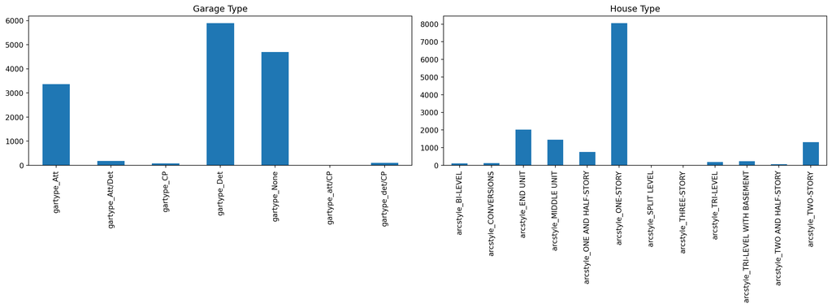

```python
import matplotlib.pyplot as plt

time = df.query("yrbuilt < 1980 ").sum()

house_type = time[['arcstyle_BI-LEVEL','arcstyle_CONVERSIONS', 'arcstyle_END UNIT','arcstyle_MIDDLE UNIT','arcstyle_ONE AND HALF-STORY','arcstyle_ONE-STORY','arcstyle_SPLIT LEVEL','arcstyle_THREE-STORY','arcstyle_TRI-LEVEL','arcstyle_TRI-LEVEL WITH BASEMENT','arcstyle_TWO AND HALF-STORY','arcstyle_TWO-STORY']]



garage_type = time[['gartype_Att','gartype_Att/Det','gartype_CP','gartype_Det','gartype_None','gartype_att/CP','gartype_det/CP']]

fig, axes = plt.subplots(1, 2, figsize=(16, 6))
garage_type.plot(kind='bar', ax=axes[0])
axes[0].set_title('Garage Type')

house_type.plot(kind='bar', ax=axes[1])
axes[1].set_title('House Type')

plt.tight_layout()

plt.show()
```